# R Notebook

# RNAseq analysis of *Arabidopsis thaliana* upon enhancement of dehydration resistance by interaction with flavonoid-attracted *Aeromonas* sp. from root microbiome

#### Authors:

Julio Ramírez Guerrero, Julián Román Camacho, Silvestre Ruano Rodríguez, Manuel Racero de la Rosa, Rafael Rubio Ramos.

## Introduction

### Background

In view of the current alarming climatic problems, the aim is to find plants that can withstand abiotic stress conditions. Flavonoids (a secondary metabolite synthesised by the plant when under stress) can be of great help in determining the plant-microbiome relationship, and to see how this improves resistance to water stress. This relationship is well studied in nodulating bacterial species, but not so much in non-nodulating bacteria such as those of the Aeromonadaceae family. Therefore, the motivation of the study is to check the behaviour of *Arabidopsis thaliana* plants in the presence/absence of *Aeromonas* sp.

### Objective

To test differential expression in *Arabidopsis thaliana*, in the presence/absence of *Aeromonas* sp. and drought conditions.

## Materials and Methods

### Experimental Design

For our experimental design we have used as a reference the accession number GSE184872 of the GEO (Gene Expression Omnibus) website.

We have a series of points that describe the conditions of our study, according to the treatment we have applied to *Arabidopsis thaliana*, the plant that is the model organism of this study.

- Untreated (Controls):
  - GSM5599109 At_mock_1
  - GSM5599110 At_mock_2
  - GSM5599111 At_mock_3
- Drought treatment:
  - GSM5599112 At_Drought_1
  - GSM5599113 At_Drought_2
  - GSM5599114 At_Drought_3
- Aeromonas treatment:
  - GSM5599115 At_H1_1
  - GSM5599116 At_H1_2
  - GSM5599117 At_H1_3
- Drought and aeromonas treatments:
  - GSM5599118 At_H1_Drought_1
  - GSM5599119 At_H1_Drought_2
  - GSM5599120 At_H1_Drought_3

### Workflow

The following is the series of steps followed to perform the mathematical/computational analysis of the RNA-seq data.

Firstly, the linux workspace is prepared, here the data is taken from the reference article and downloaded via sbatch. This will provide both .gz and .gtf files. Using a fastq-dump the SRA files are converted to FASTQ, then the fastqc quality analysis of the fastq.gz files is performed and checked to ensure that they are correctly analysed without contamination or other alteration.

Next, hisat2 will be executed on the fastq.gz and thus, the short sequence reads will be mapped against the reference genome, giving .sam files that are too heavy and inefficient when manipulating the data, so they are transferred to .bam using samtools, thus obtaining files of less weight. The indexes will also be generated. With the hisat2 alignments, the transcripts of our .bam are assembled with the stringtie tool. Once each of the samples has been assembled in the corresponding .gtf, it is necessary to compile the complete transcriptome, so the .gtf are joined with the stringtie merge tool. Once the complete transcriptome is obtained, gene expression is quantified.

The analysis is continued in the R program. With the ballgown library, the previously obtained expression data are read, the 4 conditions of the analysis are established, each one with its 3 replicates. The expression levels are extracted for both FPKM and TPM, then the data are normalised and the boxplots before and after normalisation are compared. The difference between replicates is checked with a scatterplot. With PCA and hierarchical clustering analysis the different distributions of the groups and their variability are verified. The expression matrix is used to cluster the data and check their distribution with scatterplots representing the different conditions and volcano plots to study the biological magnitude of the differences in gene expression between different experimental conditions. And finally, functional enrichment to highlight which biological processes are most represented.

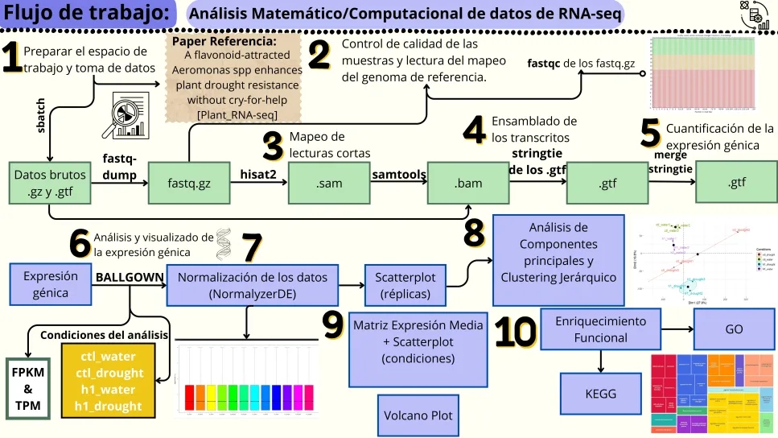

RNAseq Workflow.